# Les catégories d’inscription dans le FHS

Cette fiche détaille les changements intervenus sur les inscrits à France Travail à la suite de l’instauration de la Loi sur le plein emploi le 1er janvier 2025. Elle apporte des précisions sur les nouvelles catégories F et G (table cat9_10) et propose une manière de reconstituer l’ensemble des catégories d’inscrits, en identifiant les personnes radiées en raison d’un défaut d’actualisation hybride (table rad_actuh).

# Les nouvelles catégories F et G

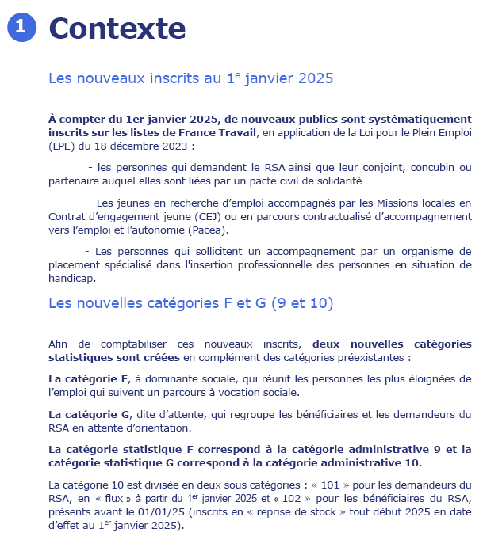

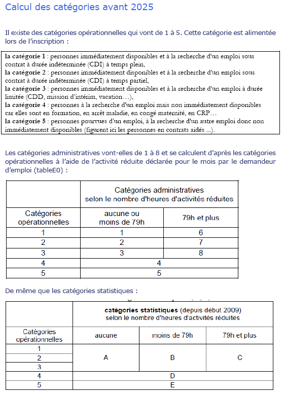

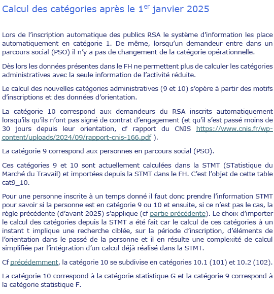

# Précisions sur la table cat9_10

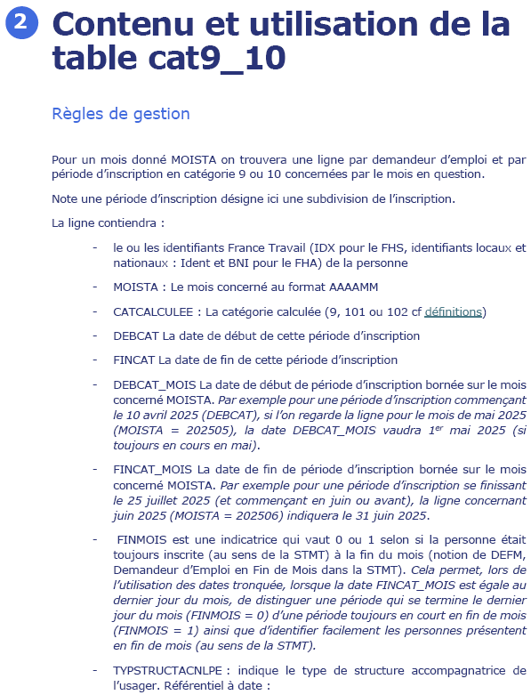

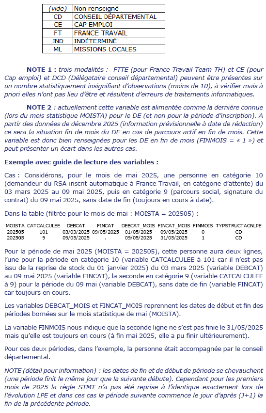

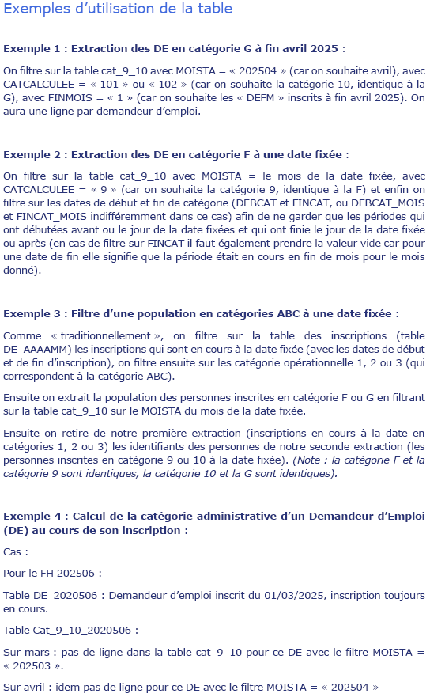

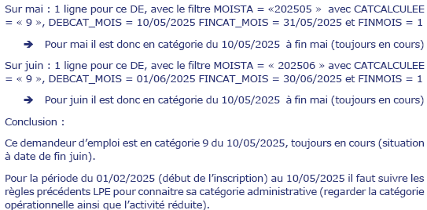

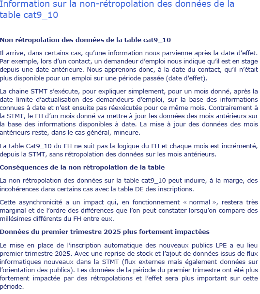